# Practical Machine Learning Course Project

Charles Smith

December 15, 2016

## Background

Using devices such as *Jawbone Up*, *Nike FuelBand*, and *Fitbit* it is now possible to collect a large amount of data about personal activity relatively inexpensively. These types of devices are part of the quantified self movement - a group of enthusiasts who take measurements about themselves regularly to improve their health, to find patterns in their behavior, or because they are tech geeks. One thing that people regularly do is quantify how *much* of a particular activity they do, but they rarely quantify *how well they do it*. In this project, the goal will be to use data from accelerometers on the belt, forearm, arm, and dumbell of 6 participants who were asked to perform barbell lifts correctly and incorrectly in 5 different ways. More information is available from the [Human Activity Recognition](http://groupware.les.inf.puc-rio.br/har) website (see the section on the Weight Lifting Exercise Dataset).

## Data

The training data for this project is available here: [Training Data](https://d396qusza40orc.cloudfront.net/predmachlearn/pml-training.csv)

The test data is available here: [Test Data](https://d396qusza40orc.cloudfront.net/predmachlearn/pml-testing.csv)

The [Human Activity Recognition](http://groupware.les.inf.puc-rio.br/har) project has been very generous in allowing their data to be used for this assignment.

## Project Instructions

The goal of this project is to predict the manner in which the participants did the exercise. This is the “classe” variable in the training set (Class A corresponds to the specified execution of the exercise, while the other 4 classes correspond to common mistakes).

You may use any of the other variables to predict with. You should create a report describing how you built your model, how you used cross validation, what you think the expected out of sample error is, and why you made the choices you did. You will also use your model to predict 20 different test cases.

## Getting and Cleaning the Data

```r
trainingUrl <- "https://d396qusza40orc.cloudfront.net/predmachlearn/pml-training.csv"
# download.file(trainingUrl,destfile="pml-training.csv")

testingUrl <- "https://d396qusza40orc.cloudfront.net/predmachlearn/pml-testing.csv"
# download.file(testingUrl,destfile="pml-testing.csv")

# setwd("c:/Users/Chuck/Documents/Coursera/PracticalMachineLearning")

trainingData <- read.csv("pml-training.csv",header=TRUE)
testingData <- read.csv("pml-testing.csv",header=TRUE)

dim(trainingData)
```

```
## [1] 19622   160
```

```r
dim(testingData)
```

```
## [1]  20 160
```

A visual inspection of the data in Excel shows a lot of missing data (NA or empty string). I will use the exercise variables (belt, arm, dumbbell, and forearm variables) that have complete data as the predictors for the classe variable.

```r
missingValues <- sapply(trainingData,function(x) any(is.na(x) | x == ""))
predictors <- (missingValues == FALSE) & grepl("belt|[^(fore)]arm|dumbbell|forearm",names(missingValues))
predictors <- names(missingValues)[predictors]
predictors
```

```
##  [1] "roll_belt"            "pitch_belt"           "yaw_belt"
##  [4] "total_accel_belt"     "gyros_belt_x"         "gyros_belt_y"
##  [7] "gyros_belt_z"         "accel_belt_x"         "accel_belt_y"
## [10] "accel_belt_z"         "magnet_belt_x"        "magnet_belt_y"
## [13] "magnet_belt_z"        "roll_arm"             "pitch_arm"
## [16] "yaw_arm"              "total_accel_arm"      "gyros_arm_x"
## [19] "gyros_arm_y"          "gyros_arm_z"          "accel_arm_x"
## [22] "accel_arm_y"          "accel_arm_z"          "magnet_arm_x"
## [25] "magnet_arm_y"         "magnet_arm_z"         "roll_dumbbell"
## [28] "pitch_dumbbell"       "yaw_dumbbell"         "total_accel_dumbbell"
## [31] "gyros_dumbbell_x"     "gyros_dumbbell_y"     "gyros_dumbbell_z"
## [34] "accel_dumbbell_x"     "accel_dumbbell_y"     "accel_dumbbell_z"
## [37] "magnet_dumbbell_x"    "magnet_dumbbell_y"    "magnet_dumbbell_z"
## [40] "roll_forearm"         "pitch_forearm"        "yaw_forearm"
## [43] "total_accel_forearm"  "gyros_forearm_x"      "gyros_forearm_y"
## [46] "gyros_forearm_z"      "accel_forearm_x"      "accel_forearm_y"
## [49] "accel_forearm_z"      "magnet_forearm_x"     "magnet_forearm_y"
## [52] "magnet_forearm_z"
```

```r
trainingData <- trainingData[,c("classe",predictors)]
dim(trainingData)
```

```
## [1] 19622    53
```

```r
library(caret)
library(lattice)
```

```r
set.seed(33)
# split into 60% training, 40% testing
trainingSet <- createDataPartition(trainingData$classe, p=0.6, list=FALSE)
trainingPartition <- trainingData[trainingSet,]
testPartition <- trainingData[-trainingSet,]
dim(trainingPartition)
```

```
## [1] 11776    53
```

```r
dim(testPartition)
```

```
## [1] 7846   53
```

## Cross-Validation

```r
# Control Parameters for Train - preprocessing and K-fold (10-fold) cross validation
centered_scaled = c("center","scale")
train_ctl <- trainControl(method = "cv", number = 10)

# gradient boosting
gradBoostModel <- train(classe ~ .,
                       data = trainingPartition,
                       method = "gbm",
                       metric = "Kappa",
                       preProcess = centered_scaled,
                       trControl = train_ctl,
                       verbose = FALSE)

# random forest
randomForestModel <- train(classe ~ .,
                          data = trainingPartition,
                          method = "rf",
                          metric = "Kappa",
                          preProcess = centered_scaled,
                          trControl = train_ctl)

modelCompare <- resamples(list(randomForest = randomForestModel, gradientBoost = gradBoostModel))
summary(modelCompare)
```

```
##
## Call:
## summary.resamples(object = modelCompare)
##
## Models: randomForest, gradientBoost
## Number of resamples: 10
##
## Accuracy
##                 Min. 1st Qu. Median   Mean 3rd Qu.   Max. NA's
## randomForest  0.9864  0.9892 0.9924 0.9913  0.9932 0.9941    0
## gradientBoost 0.9533  0.9586 0.9605 0.9613  0.9652 0.9669    0
##
## Kappa
##                 Min. 1st Qu. Median   Mean 3rd Qu.   Max. NA's
## randomForest  0.9828  0.9863 0.9903 0.9889  0.9914 0.9925    0
## gradientBoost 0.9409  0.9476 0.9501 0.9510  0.9560 0.9581    0
```

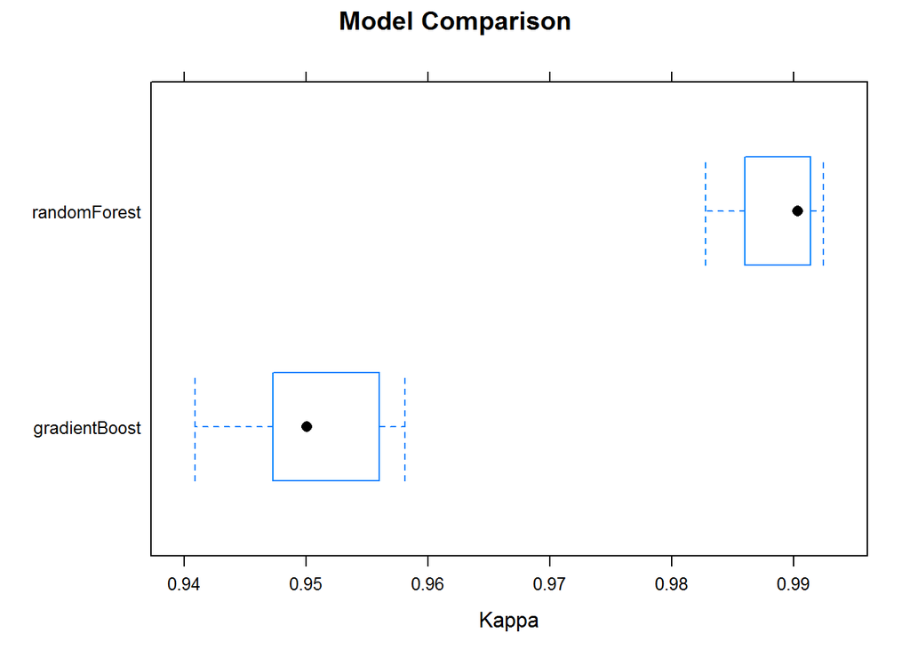

```r
bwplot(modelCompare, metric = "Kappa", main = "Model Comparison")
```

```r
randomForestModel
```

```
## Random Forest
##
## 11776 samples
##    52 predictor
##     5 classes: 'A', 'B', 'C', 'D', 'E'
##
## Pre-processing: centered (52), scaled (52)
## Resampling: Cross-Validated (10 fold)
## Summary of sample sizes: 10598, 10600, 10598, 10598, 10598, 10598, ...
## Resampling results across tuning parameters:
##
##   mtry  Accuracy   Kappa
##    2    0.9912540  0.9889354
##   27    0.9906593  0.9881836
##   52    0.9824216  0.9777619
##
## Kappa was used to select the optimal model using  the largest value.
## The final value used for the model was mtry = 2.
```

The random forest model has the highest accuracy rate so that’s the model I will go forward with.

## Test the Model Using the Test Data Partition

```r
predictTest <- predict(randomForestModel, testPartition)
confusionMatrix(testPartition$classe, predictTest)
```

```
## Confusion Matrix and Statistics
##
##           Reference
## Prediction    A    B    C    D    E
##          A 2226    4    1    0    1
##          B    9 1504    5    0    0
##          C    0    9 1358    1    0
##          D    0    0   35 1247    4
##          E    0    0    2    2 1438
##
## Overall Statistics
##
##                Accuracy : 0.9907
##                  95% CI : (0.9883, 0.9927)
##     No Information Rate : 0.2849
##     P-Value [Acc > NIR] : < 2.2e-16
##
##                   Kappa : 0.9882
##  Mcnemar's Test P-Value : NA
##
## Statistics by Class:
##
##                      Class: A Class: B Class: C Class: D Class: E
## Sensitivity            0.9960   0.9914   0.9693   0.9976   0.9965
## Specificity            0.9989   0.9978   0.9984   0.9941   0.9994
## Pos Pred Value         0.9973   0.9908   0.9927   0.9697   0.9972
## Neg Pred Value         0.9984   0.9979   0.9934   0.9995   0.9992
## Prevalence             0.2849   0.1933   0.1786   0.1593   0.1839
## Detection Rate         0.2837   0.1917   0.1731   0.1589   0.1833
## Detection Prevalence   0.2845   0.1935   0.1744   0.1639   0.1838
## Balanced Accuracy      0.9975   0.9946   0.9839   0.9958   0.9980
```

```r
# show the expected out of sample error (OOB estimate of error rate)
randomForestModel$finalModel
```

```
##
## Call:
##  randomForest(x = x, y = y, mtry = param$mtry)
##                Type of random forest: classification
##                      Number of trees: 500
## No. of variables tried at each split: 2
##
##         OOB estimate of  error rate: 0.79%
## Confusion matrix:
##      A    B    C    D    E  class.error
## A 3345    1    1    1    0 0.0008960573
## B   14 2256    9    0    0 0.0100921457
## C    0   22 2027    5    0 0.0131450828
## D    0    0   33 1895    2 0.0181347150
## E    0    0    3    2 2160 0.0023094688
```

The expected out of sample error (OOB estimate of error rate) is 0.79%

## Test Using the Test Data File (pml_testing.csv)

```r
finalTestData <- testingData[,which(names(testingData) %in% names(trainingData))]
finalTest <- predict(randomForestModel, newdata=finalTestData)
finalTestDf <- as.data.frame(finalTest)
finalTestDf
```

```
##    finalTest
## 1          B
## 2          A
## 3          B
## 4          A
## 5          A
## 6          E
## 7          D
## 8          B
## 9          A
## 10         A
## 11         B
## 12         C
## 13         B
## 14         A
## 15         E
## 16         E
## 17         A
## 18         B
## 19         B
## 20         B
```

```r
# Prepare the test data predictions for submission
pml_write_files = function(x) {
        n = length(x)
        for (i in 1:n) {
                filename = paste0("problem_id_",i,".txt")
                write.table(x[i],file=filename,quote=FALSE,row.names=FALSE,col.names=FALSE)
        }
}
pml_write_files(finalTest)
```